# Final Report

Final Project  
Data Science 2 with R (STAT 301-2)

Author

Chiemela Onuoha

Published

March 20, 2025

**Github Repo Link**

[Chiemela’s Github (chiemelaonu)](https://github.com/stat301-2-2025-winter/final-project-2-chiemelaonu.git)

## Introduction

The objective of this report is to present findings of predictive modeling done on a movies dataset. I would like to see how well a movies’ revenue can be predicted using other features of the movie/data.  
These predictions are useful because having an accurate prediction model for movie revenue could be highly valuable for investors and filmmakers because it would help estimate a film’s financial success before release. That would allow for better budget allocation, and even optimize marketing strategies.

## Data Overview

Below is a table showing the attributes of our movies dataset, like the column type and number of missing variables. With this table, we see that there are very few missing values, and those that are missing are present in the genre and crew columns. The main purpose of this check is to see any missingness in the target variable, which is not present in this data.

Table 1: Skim of Missing Data

| skim_type | skim_variable | n_missing | complete_rate | character.min | character.max | character.empty | character.n_unique | character.whitespace | numeric.mean | numeric.sd | numeric.p0 | numeric.p25 | numeric.p50 | numeric.p75 | numeric.p100 |
| --- | --- | --- | --- | --- | --- | --- | --- | --- | --- | --- | --- | --- | --- | --- | --- |
| character | names | 0 | 1.0000000 | 1 | 98 | 0 | 9660 | 0 | NA | NA | NA | NA | NA | NA | NA |
| character | date_x | 0 | 1.0000000 | 10 | 10 | 0 | 5688 | 0 | NA | NA | NA | NA | NA | NA | NA |
| character | genre | 85 | 0.9916487 | 3 | 86 | 0 | 2303 | 0 | NA | NA | NA | NA | NA | NA | NA |
| character | overview | 0 | 1.0000000 | 12 | 998 | 0 | 9905 | 0 | NA | NA | NA | NA | NA | NA | NA |
| character | crew | 56 | 0.9944979 | 8 | 1357 | 0 | 9927 | 0 | NA | NA | NA | NA | NA | NA | NA |
| character | orig_title | 0 | 1.0000000 | 1 | 86 | 0 | 9730 | 0 | NA | NA | NA | NA | NA | NA | NA |
| character | status | 0 | 1.0000000 | 8 | 15 | 0 | 3 | 0 | NA | NA | NA | NA | NA | NA | NA |
| character | orig_lang | 0 | 1.0000000 | 4 | 35 | 0 | 54 | 0 | NA | NA | NA | NA | NA | NA | NA |
| character | country | 0 | 1.0000000 | 2 | 2 | 0 | 60 | 0 | NA | NA | NA | NA | NA | NA | NA |
| numeric | score | 0 | 1.0000000 | NA | NA | NA | NA | NA | 6.349705e+01 | 1.353701e+01 | 0 | 59 | 65 | 71 | 100 |
| numeric | budget_x | 0 | 1.0000000 | NA | NA | NA | NA | NA | 6.488238e+07 | 5.707565e+07 | 1 | 15000000 | 50000000 | 105000000 | 460000000 |
| numeric | revenue | 0 | 1.0000000 | NA | NA | NA | NA | NA | 2.531401e+08 | 2.777880e+08 | 0 | 28588985 | 152934876 | 417802077 | 2923706026 |

The table below provides a more concise skimming of the data, telling us that we have just under 10,200 observations, 12 columns, 126 rows with missing values.

Table 2: Dataset Summary

| Metric | Value |
| --- | --- |
| Rows with Missing Values | 126 |
| Number of Observations | 10178 |
| Number of Variables | 12 |
| Number of Missing Target Variable Observations (`revenue`) | 0 |

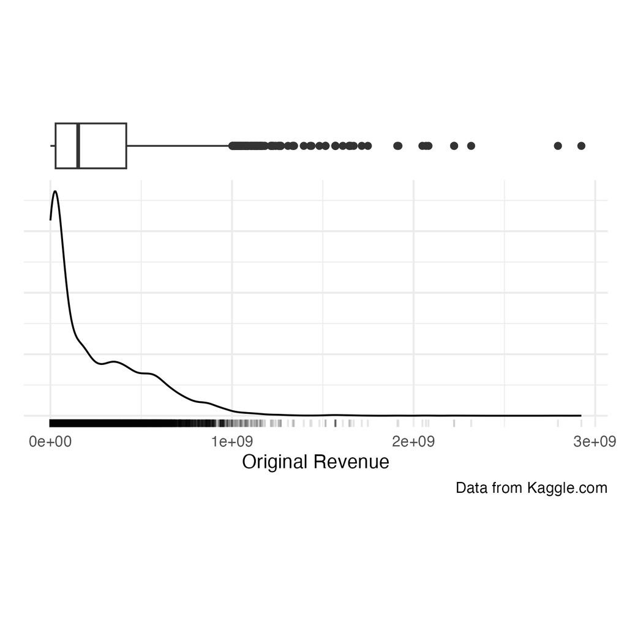

(a) revenue on Original Scale ($)

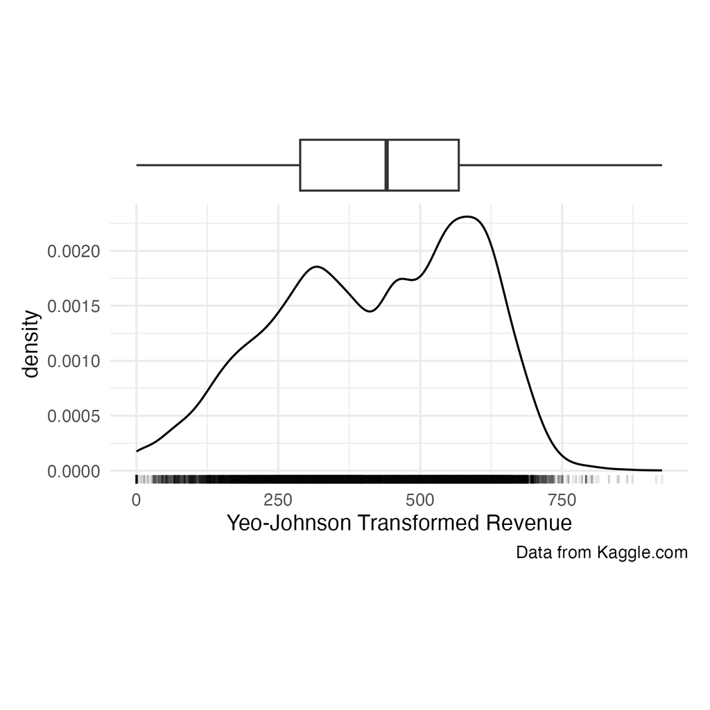

(b) revenue Transformed with Yeo-Johnson

Figure 1

On the left, we have the original distribution of the target variable, `revenue`, visualized with a density plot and box plot. The original values were heavily skewed right, so it was apparent a transformation of revenue was needed. After experimenting with log, Yeo-Johnson, square root, and Box-Cox transformations, I settled on a Yeo-Johnson transformation to make the values more evenly distributed.[^1]  
The Yeo-Johnson transformation reshapes data to make it more normal by adjusting values differently based on whether they are positive or negative. For positive numbers, it applies a power transformation or a log function, while for negative numbers, it flips them, transforms them, and flips them back. The density and box plot on the right shows those values post-transformation.

<sup>1</sup> A lambda value of 0.25 was used

### Data Wrangling

The movies dataset initially had 12 columns and I was only able to extract 3 predictors for my models, but I have been able to conduct more manipulation of the data to allow for more usable predictors in my models.

Table 3: Movies Data with Added Columns

```
Rows: 10,178
Columns: 18
$ names             <chr> "Creed III", "Avatar: The Way of Water", "The Super …
$ score             <dbl> 73, 78, 76, 70, 61, 66, 80, 83, 59, 58, 58, 55, 65, …
$ genre             <chr> "Drama, Action", "Science Fiction, Adventure, Action…
$ overview          <chr> "After dominating the boxing world, Adonis Creed has…
$ crew              <chr> "Michael B. Jordan, Adonis Creed, Tessa Thompson, Bi…
$ orig_title        <chr> "Creed III", "Avatar: The Way of Water", "The Super …
$ status            <chr> "Released", "Released", "Released", "Released", "Rel…
$ orig_lang         <chr> "English", "English", "English", "Spanish, Castilian…
$ budget_x          <dbl> 75000000, 460000000, 100000000, 12300000, 77000000, …
$ revenue           <dbl> 271616668, 2316794914, 724459031, 34200000, 34094195…
$ country           <chr> "AU", "AU", "AU", "AU", "US", "AU", "AU", "AU", "US"…
$ negative          <dbl> 2, 2, 1, 2, 4, 2, 1, 2, 2, 1, 0, 10, NA, 1, 2, 0, 5,…
$ positive          <dbl> 3, 1, 1, 2, 3, 0, 3, 1, 5, 0, 1, 3, NA, 1, 0, 2, 0, …
$ overall_sentiment <chr> "Positive", "Negative", "Neutral", "Neutral", "Negat…
$ num_crew          <dbl> 9, 9, 9, 9, 9, 9, 9, 9, 9, 9, 9, 8, 9, 9, 9, 7, 9, 9…
$ date              <date> 2023-03-02, 2022-12-15, 2023-04-05, 2023-01-05, 202…
$ num_genres        <dbl> 2, 3, 5, 5, 1, 3, 3, 5, 2, 5, 2, 1, 3, 3, 2, 2, 4, 2…
$ yeo_revenue       <dbl> 509.5102, 873.5702, 652.2411, 301.8909, 539.5382, 37…
```

In the table above, you can see that I added a column called `num_genres` that has the counts of the genres for each movie. I added columns `negative`, `positive`, and `overall_sentiment` that uses the `tidytext` package to parse the `overview` column and note which words are positive or negative. The `positive` and `negative` columns hold the counts of those kinds of words present in each observation, and the `overall_sentiment` column gives the overall sentiment: Negative, Positive, or Neutral, depending on how many of each kind was counted. Lastly, I added a column called `num_crew` that counts the number of crew members listed for each movie. These new columns will serve as better features for my model, in the hopes of creating more accurate and meaningful predictions.

## Methods

### Data Splitting

I decided on a split proportion of 80/20 because it gives an optimal amount of data in the testing and training sets. I also used the default number of strata and stratified by our target variable, `yeo_revenue` (the Yeo-Johnson transformed revenue).

#### Resampling

I will be using V-fold cross-validation for resampling, with 5 folds (V) and 3 repeats. This method is useful because it ensures that each data point is used for both training and testing, providing a more reliable estimate of model performance.

### Metrics

The metric I used for comparing and selecting a final model is Mean Absolute Error (MAE). MAE measures the average magnitude of the errors between the predicted and actual values, without considering their direction. I picked MAE as my metric because it is commonly used in regression modeling and is a relatively simple metric to interpret and explain.

### Model Descriptions

This is a regression problem because the target variable, revenue, is continuous rather than categorical. Since it is a regression problem, I knew I would like to fit/tune a Null/Baseline model, an OLS model, EN models, a Random Forest Model, a Boosted Trees model, and a K-Nearest Neighbors model.

#### Null/Baseline

A null model is a simple model that based solely on the mean (for regression). It serves as a basic reference to compare the performance of more complex models.  
A baseline model is a simple predictive model used as a benchmark. Its use is to set a reasonable lower bound for predictive performance. Comparing against a baseline helps measure whether advanced modeling techniques provide meaningful improvement.

#### OLS

An Ordinary Least Squared (OLS) model is used for when relationships are linear, features are independent, and interpretability is needed. An OLS model captures linear relationships, effect sizes, and predictor significance well, and is a almost always one of the first models to be used in a regression problem. It provides another fairly simple benchmark for our model.

#### Elastic Net

Elastic Net (EN) is a regularized regression method that combines Ridge and Lasoo penalties. It stabilizes coefficient estimates like Ridge while also eliminating irrelevant variables like Lasso. EN is particularly useful when predictors are highly correlated, when there are more features than observations, or when handling noisy or sparse data.  
In EN, the `penalty` controls how much the model shrinks the coefficients, with higher values forcing them closer to zero. The `mixture` decides the balance between Lasso, which can set some coefficients to zero, and Ridge, which shrinks them without making any exactly zero. A mixture of 1 is pure Lasso, 0 is pure Ridge, and values in between blend both.  
The hyperparameters I will be tuning are `mixture` and `penalty`.

#### Random Forest

Random Forest is an ensemble learning method that builds multiple decision trees and averages their predictions to improve accuracy and reduce overfitting. It is ideal for capturing nonlinear relationships and handling high-dimensional data.  
In Random Forest, `mtry` is the number of features randomly chosen at each split, affecting how diverse the trees are. `min_n` is the minimum number of data points needed in a node before it can split, controlling how deep the trees grow.  
The hyperparameters I will be tuning are `min_n` with a range of 2-40, and `mtry` with a range of 1-10.

#### Boosted Trees

Boosted trees is a method that builds decision trees sequentially, where each tree corrects the errors of the previous one, leading to high predictive accuracy and strong performance on complex datasets.  
In Boosted Trees, we have `mtry` and `min_n` as hyperparamaters as well. `learn_rate` controls how much each tree contributes to the final prediction, with lower values leading to slower but more stable learning. `tree_depth` sets how deep each tree can grow, balancing complexity and overfitting.  
The hyperparameters I will be tuning are `min_n` with a range of 2-40, `mtry` with a range of 1-10, `learn_rate` with a range of -5 to -0.2, and a `tree_depth` range of 6 to 10.

#### K-Nearest Neighbors

K-Nearest Neighbors (KNN) is a non-parametric model that classifies or predicts values based on the majority vote of nearby data points or their average. It works well for nonlinear relationships.  
The hyperparameter I will be tuning is `neighbors`.  
In K-Nearest Neighbors (KNN), the `neighbors` parameter sets how many nearby points the model looks at when making a prediction. A small values makes the model sensitive to noise, while a large value smooths predictions but may miss local patterns. Choosing the right value balances accuracy and generalization.

**Important**

There are no hyperparamaters to tune for the Null/Baseline or OLS models, as the model is fit to the resamples as normal.

### Recipes

There are 2 recipes defined for each model (or set of models in the case of the EN models), excluding the Null/Baseline models that use only one recipe. There is each a “basic” recipe and a “complex” recipe used for the models.

#### Null/Baseline Model Recipe

The first recipe was for the null and baseline models. My first step was to impute the mean of all missing numerical values. I also imputed the mode of the `overall_sentiment` column because of NAs. Next, I used `step_date()` to extract the year and month out of the date column to use as predictors. Lastly, I used `step_dummy()` to one-hot encode the `overall_sentiment` column so that all 3 types of sentiments are captured and used as predictors.

#### Linear Model Recipes

For my complex Linear model recipe, most of the steps are the same as the null/baseline recipe, except I used `step_interact()` to create an interaction with 2 sets of predictors I feel would work together in this predictive process, and used `step_normalize()` to scale and center the numerical predictors to prevent multicollinearity. I also added a Yeo-Johnson transformation of the `budget_x` column. For my basic Linear model recipe has everything previously stated, except the interactions and the `budget_x` transformation.

#### Tree Based Model Recipes

For my basic tree model recipe, I kept the same steps as my basic Linear model recipe. For my complex recipe, I created a new column called `season` that splits up the months into the 4 seasons and used that as a predictor as well.

## Model Building and Selection Results

### Basic Workflows

Table 4: Basic Random Forest Best Hyperparameters

| mtry | min_n | Model_Type |
| --- | --- | --- |
| 10 | 11 | Random Forest |

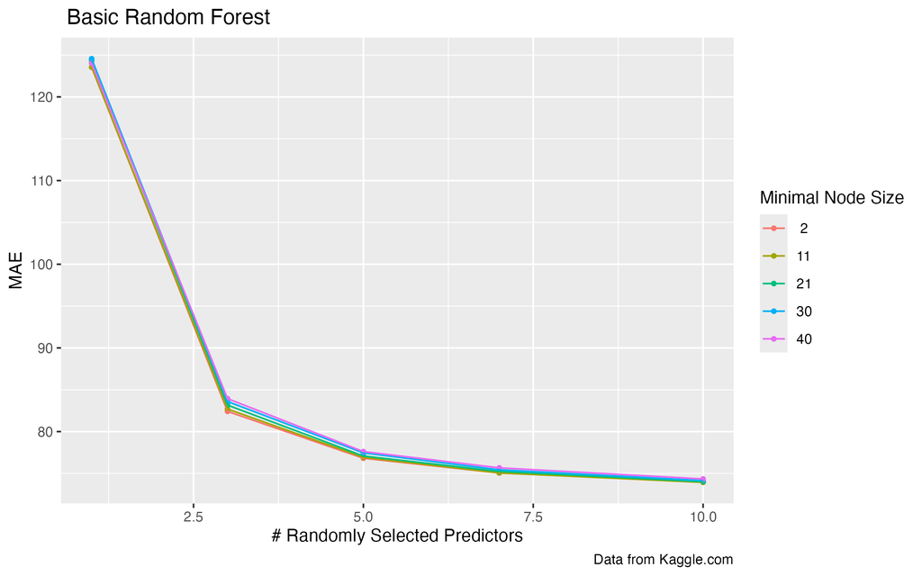

(a) Basic Random Forest Workflow Plot

Figure 2

The Random Forest Workflow’s best hyperparameters are an `mtry` of 10 and `min_n` of 11. The MAE had a steep decline in the beginning and began to level out at an `mtry` of 5.

Table 5: Basic KNN Best Hyperparameters

| neighbors | Model_Type |
| --- | --- |
| 10 | K-Nearest Neighbor |

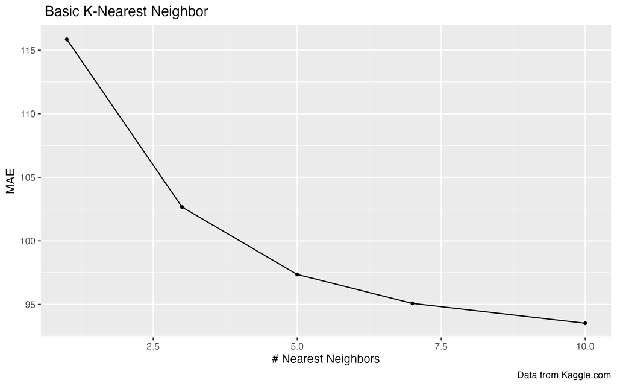

(a) Basic K-Nearest Neighbor Workflow Plot

Figure 3

Figure 3 and Table 5 show that the KNN best hyperparamters are a `neighbors` value of 10.

Table 6: Basic Boosted Trees Best Hyperparameters

| mtry | min_n | tree_depth | learn_rate | Model_Type |
| --- | --- | --- | --- | --- |
| 10 | 2 | 9 | 0.0398107 | Boosted Trees |

Table 7: Basic Elastic Net Best Hyperparameters

| penalty | mixture | Model_Type |
| --- | --- | --- |
| 0.5 | 1 | Elastic Net |

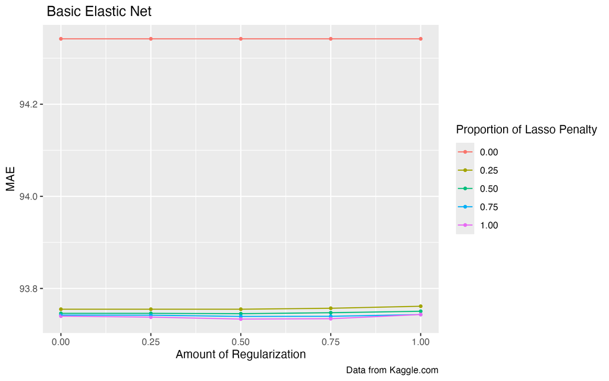

(a) Basic Elastic Net Workflow Plot

Figure 4

EN’s best hyperparameters are a `mixture` of 1 and a `penalty` of 0.5, which is a Lasso model.

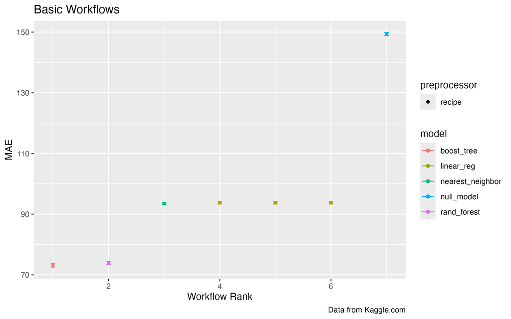

(a) Basic Workflow Plot

Figure 5

Table 8: Basic Model Results

| Model Type | MAE | Std Error | n |
| --- | --- | --- | --- |
| bt | 73.1161 | 0.3557 | 15 |
| rf | 73.9316 | 0.2997 | 15 |
| knn | 93.5128 | 0.2134 | 15 |
| en | 93.7335 | 0.2472 | 15 |
| lm | 93.7535 | 0.2453 | 15 |
| baseline | 93.7535 | 0.2453 | 15 |
| null | 149.3789 | 0.2950 | 15 |

Table 8 shows the more precise MAE’s for the “basic” workflows. The MAE of null model is significantly higher than the rest, at about 149. KNN has an MAE of about 93.5. The baseline, EN, and Linear model are all around the same MAE values of about 93.7. Then, Random Forest and Boosted Trees have a significant drop to around 73.9 and 73.1, respectively.

### Complex Workflows

Table 9: Complex Random Forest Best Hyperparameters

| mtry | min_n | Model_Type |
| --- | --- | --- |
| 10 | 11 | Random Forest |

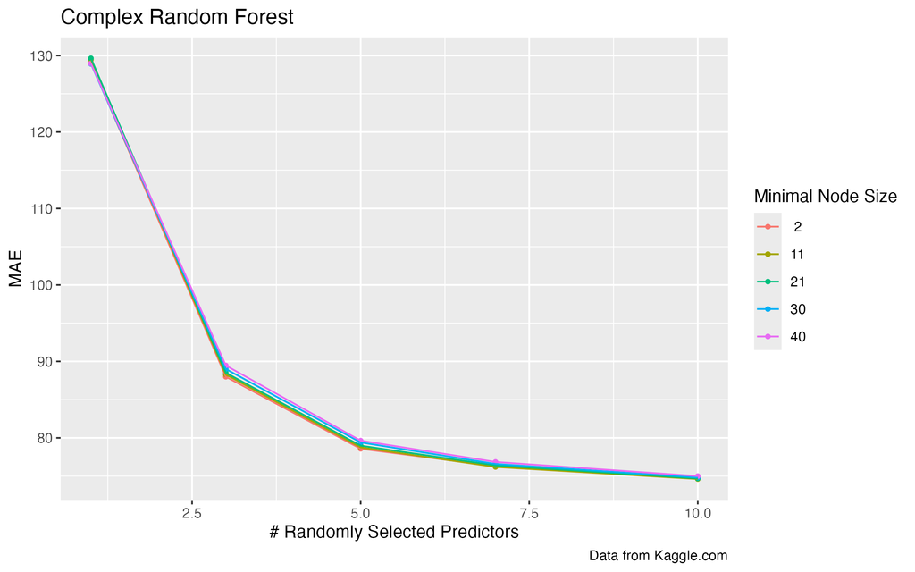

(a) Complex Random Forest Workflow Plot

Figure 6

The complex Random Forest workflow’s best hyperparamters are an `mtry` of 10 and an `min_n` of 11.

Table 10: Complex KNN Best Hyperparameters

| neighbors | Model_Type |
| --- | --- |
| 10 | K-Nearest Neighbor |

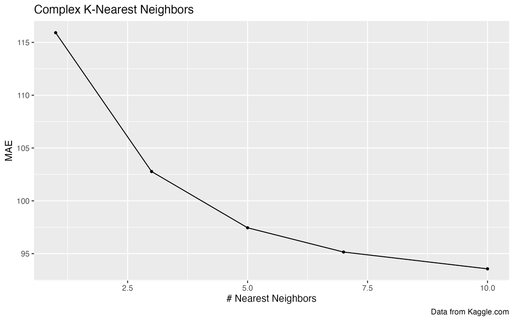

(a) K-Nearest Neighbor Complex Workflow Plot

Figure 7

The complex KNN workflow’s best hyperparameters is a `neighbors` value of 10.

Table 11: Complex Boosted Tree Best Hyperparameters

| mtry | min_n | tree_depth | learn_rate | Model_Type |
| --- | --- | --- | --- | --- |
| 10 | 2 | 8 | 0.0398107 | Boosted Trees |

Table 12: Complex Elastic Net Best Hyperparameters

| penalty | mixture | Model_Type |
| --- | --- | --- |
| 0.75 | 1 | Elastic Net |

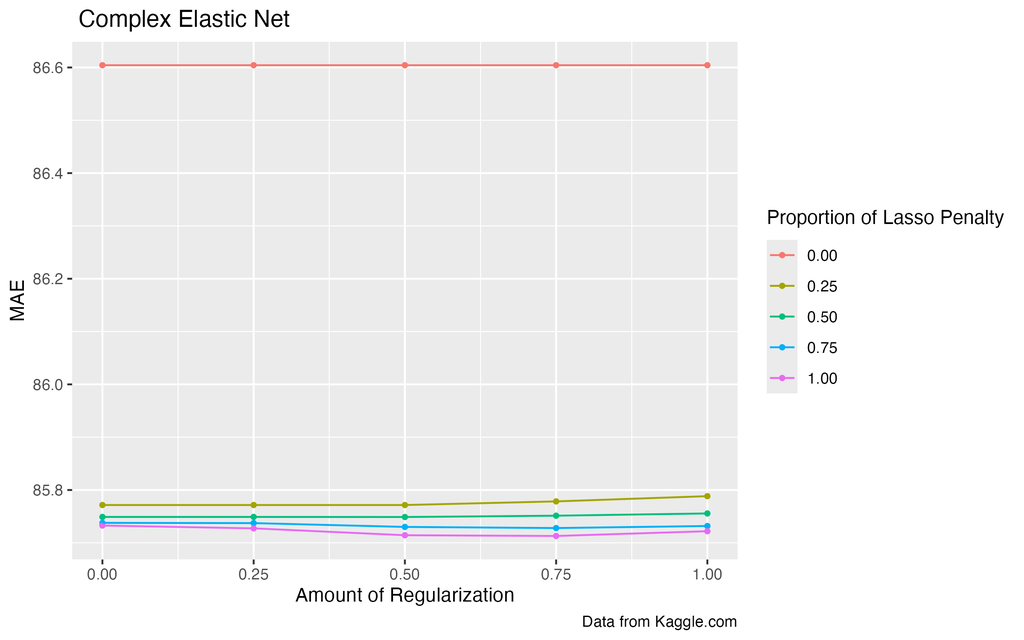

(a) Elastic Net Complex Workflow Plot

Figure 8

The complex EN workflow’s best hyperparameters are a `penalty` of 0.75 and an `mixture` of 1, which is a Lasso model again.

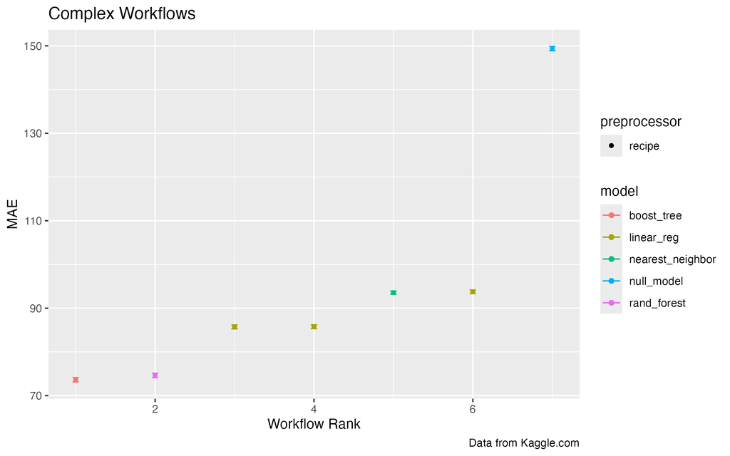

(a) Complex Workflow Plot

Figure 9

Table 13: Complex Model Results

| Model Type | MAE | Std Error | n |
| --- | --- | --- | --- |
| bt | 73.6254 | 0.2962 | 15 |
| rf | 74.6195 | 0.3022 | 15 |
| en | 85.7130 | 0.2683 | 15 |
| lm | 85.7521 | 0.2622 | 15 |
| knn | 93.5641 | 0.2176 | 15 |
| baseline | 93.7535 | 0.2453 | 15 |
| null | 149.3789 | 0.2950 | 15 |

## Final Model Analysis

After training the final model (Boosted Trees) and predicting on the test set, I calculated MAE, as well as R-squared and RMSE to provide more context on the model’s predictions. Additionally, since we used `yeo_revenue` as the target variable and not the original `revenue`, I will be transforming the values back to the original scale so that meaningful deductions can be made with the MAE.

Table 14: Final Assessment Metrics (on Yeo-Johnson Scale)

| Metric | Value |
| --- | --- |
| RMSE | 98.8236043 |
| MAE | 73.1188859 |
| R² | 0.6735839 |

Table 15: Final Assessment Metrics (on Original Scale)

| Metric | Value |
| --- | --- |
| RMSE | 170,343,822.1188754 |
| MAE | 100,211,340.5876970 |
| R² | 0.6672412 |

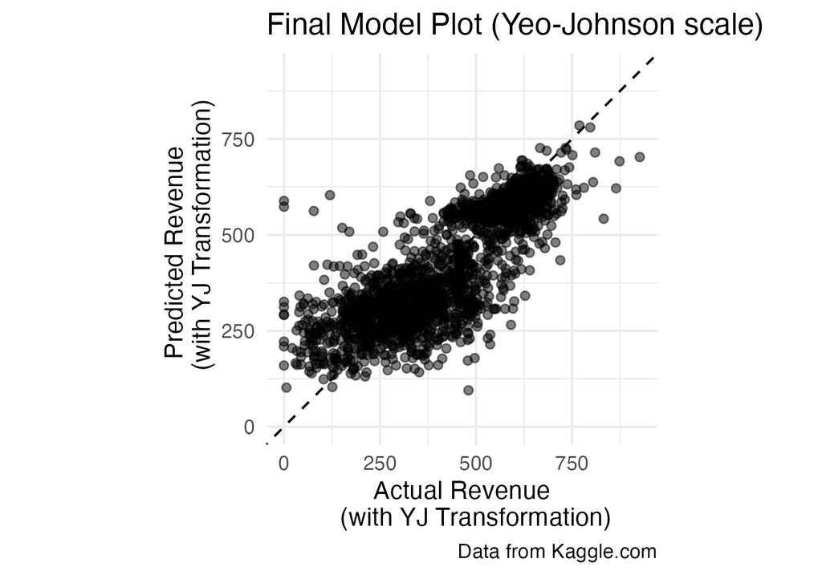

(a) Final Predictions Plot (Yeo-Johnson)

Figure 10

Figure 10 shows that the predicted revenue with the actual revenue on the Yeo-Johnson scale. The Boosted Trees model was able to make some correct or almost correct predictions, but there are still many predictions that are far off the actual values.

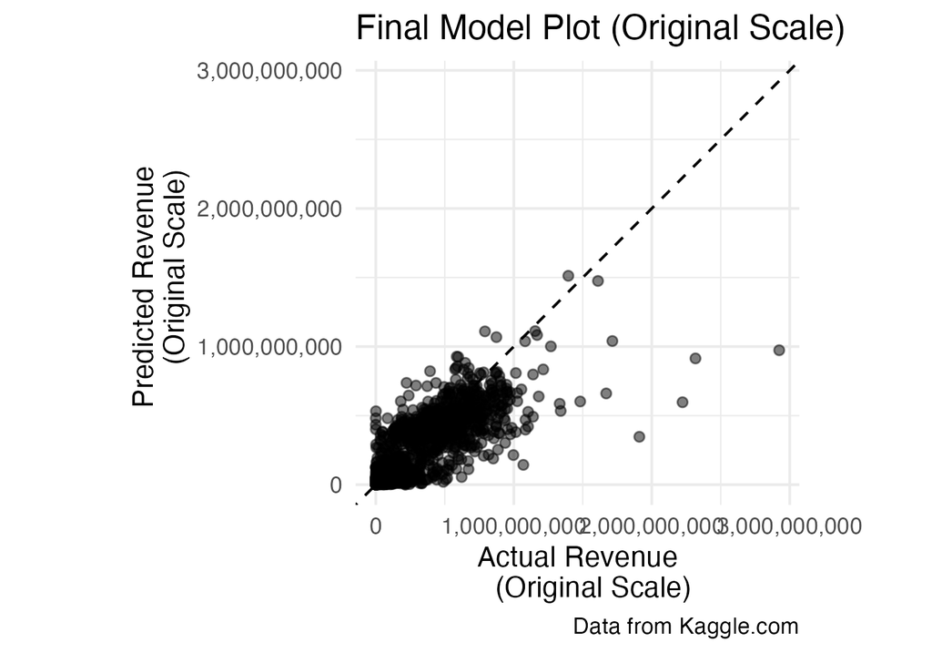

(a) Final Predictions Plot (Original)

Figure 11

Figure 11 has the predicted revenue with the actual revenue on the original scale.

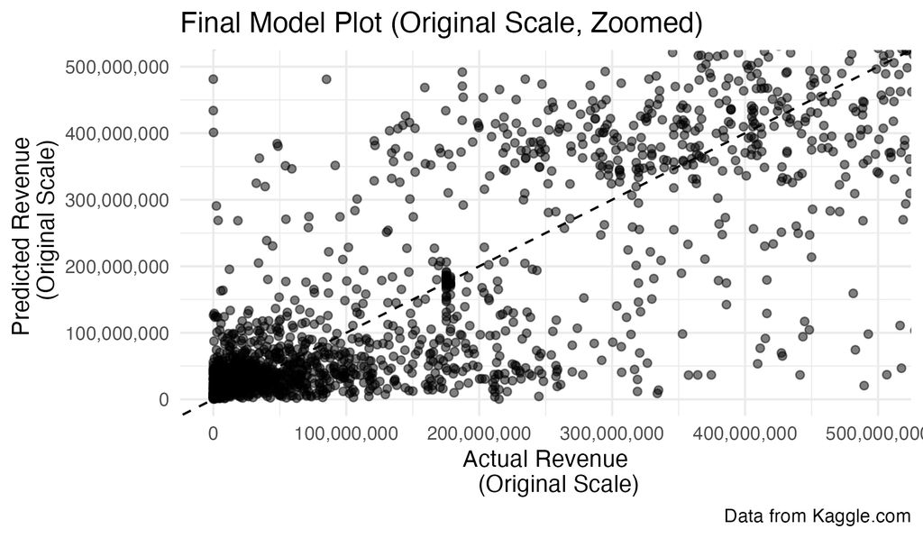

(a) Final Predictions Plot (Original)

Figure 12

To better see the outcomes of the model, Figure 12 is the distribution of the previous Figure 11 but restricted to between 0 and 500,000,000. This plot shows that there is a bit more overfitting then underfitting present (at least for this region) which can make sense since it is a Boosted Tree model and they can be prone to overfitting.

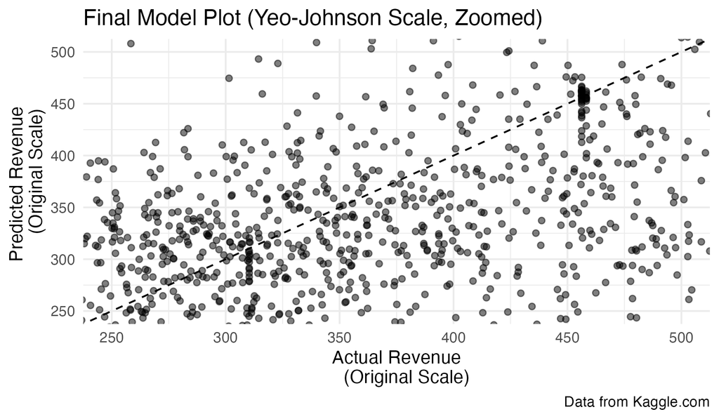

(a) Final Predictions Plot (Yeo-Johnson)

Figure 13

Figure 13 is the distribution of Figure 10 but between the range of 250 and 500, one of the clustered regions on the full dimension plot. The less-than-ideal performance of this model was foreshadowed by the R-squared value, which could mean that this prediction problem is difficult to capture in modeling. There could have been inadequate feature engineering as well, which would need to be another area of focus if exploring the reasons for the poor predictions.